# Reproducible Research: Peer Assessment 1

## Loading and preprocessing the data

```r
data <- read.csv(unz("activity.zip", "activity.csv"), header=TRUE, sep=",",  quote="\"", na.strings="NA")
data$date <- as.Date(data$date, format="%Y-%m-%d")
```

## What is mean total number of steps taken per day?

- Calculate the total number of steps taken per day

```r
total <- aggregate(data$steps, by=list(data$date), FUN=sum)
names(total) <- c("date", "totalsteps")
```

- Make a histogram of the total number of steps taken each day

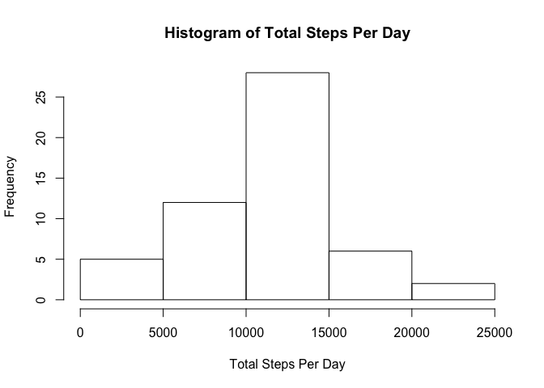

```r
hist(total$totalsteps, xlab="Total Steps Per Day", main="Histogram of Total Steps Per Day")
```

```r
stepsmean <- mean(total$totalsteps, na.rm=TRUE)
stepsmedian <- median(total$totalsteps, na.rm=TRUE)
```

## What is the average daily activity pattern?

- Make a time series plot (i.e. 𝚝𝚢𝚙𝚎 = “𝚕”) of the 5-minute interval (x-axis) and the average number of steps taken, averaged across all days (y-axis)

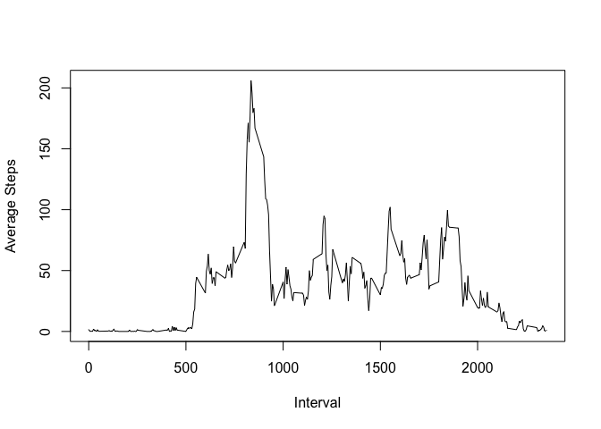

```r
daily <- aggregate(data$steps, by=list(data$interval), FUN=mean, na.rm=TRUE)
names(daily) <- c("interval", "meansteps")
plot(y=daily$meansteps, x=daily$interval, type="l", xlab="Interval", ylab="Average Steps")
```

- Which 5-minute interval, on average across all the days in the dataset, contains the maximum number of steps

```r
maxrow <- daily[daily$meansteps == max(daily$meansteps), ]
interval <- maxrow$interval
```

- Interval: 835

## Imputing missing values

- Calculate and report the total number of missing values in the dataset (i.e. the total number of rows with 𝙽𝙰s)

```r
totalmissing <- sum(is.na(data$steps))
```

- Total Rows Missing: 2304
- Devise a strategy for filling in all of the missing values in the dataset. The strategy does not need to be sophisticated. For example, you could use the mean/median for that day, or the mean for that 5-minute interval, etc.
- The average for each interval will be used to replace missing step values for intervals.
- Create a new dataset that is equal to the original dataset but with the missing data filled in.

```r
completeData <- data
for (i in 1:nrow(completeData)){
  if ( is.na(completeData[i, "steps"])) {
    completeData[i, ]$steps <- daily[daily$interval == completeData[i,]$interval,]$meansteps
  }
}
```

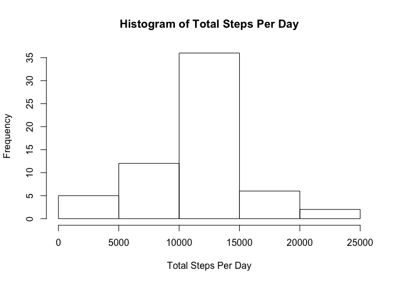

```r
total <- aggregate(completeData$steps, by=list(completeData$date), FUN=sum)
names(total) <- c("date", "totalsteps")
stepsmean <- mean(total$totalsteps, na.rm=TRUE)
stepsmedian <- median(total$totalsteps, na.rm=TRUE)
hist(total$totalsteps, xlab="Total Steps Per Day", main="Histogram of Total Steps Per Day")
```

## Are there differences in activity patterns between weekdays and weekends?

- Create a new factor variable in the dataset with two levels – “weekday” and “weekend” indicating whether a given date is a weekday or weekend day.

```r
completeData$daytype <- weekdays(completeData$date)
for(i in 1:nrow(completeData)){
  if ( completeData[i,]$daytype %in% c("Saturday", "Sunday")) {
    completeData[i,]$daytype <- "weekend"
  }
  else {
    completeData[i,]$daytype <- "weekday"
  }
}
completeData$daytype <- factor(completeData$daytype)
```

- Make a panel plot containing a time series plot (i.e. 𝚝𝚢𝚙𝚎 = “𝚕”) of the 5-minute interval (x-axis) and the average number of steps taken, averaged across all weekday days or weekend days (y-axis). See the README file in the GitHub repository to see an example of what this plot should look like using simulated data.

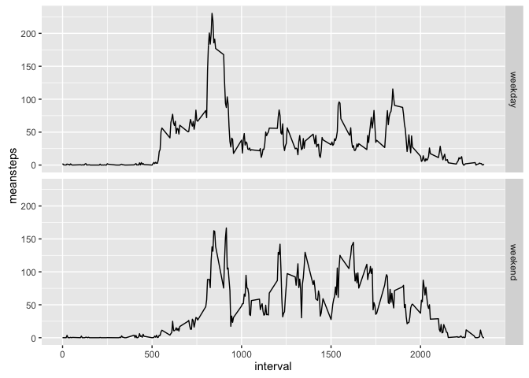

```r
daily <- aggregate(completeData$steps, by=list(completeData$interval, completeData$daytype), FUN=mean, na.rm=TRUE)
names(daily) <- c("interval", "daytype", "meansteps")
library(ggplot2, quietly=TRUE)
gp <- ggplot(daily, mapping=aes(x=interval, y=meansteps)) + geom_line() + facet_grid(daytype ~ .)
gp
```